# Superior RS Data Availability

B Steele

2023-01-20

# Purpose

This document walks through some of the remote sensing satellite options for use in creating a rasterized timeseries of presence/absence of sediment plumes and blooms. Note that this summary is limited to the Landsat constellation, MODIS/VIIRS, and HLS (Harmonized Landsat-Sentinel) as they provide 3 spatial and temporal options for raster development.

# Background

Below is the area of interest (AOI, green-shaded area) and observed blooms (yellow pins), dating back to 1998.

[figure not shown]

Figure 1. Area of interest and observations of blooms.

# Time and Scale

There is an inherent trade off between satellite image overpass frequency and the resolution (pixel size) of the satellite sensors (Table 1). Satellites with more frequent overpasses will have a larger pixel size. Note the data access differences between sources. HLS data are not yet available on GEE and require a different acquisition and processing pipeline. Note, that while VIIRS is listed here, we do not provide a summary of VIIRS data for availability. VIIRS is the ‘next generation’ of the MODIS data and unless we are going to develop the pipeline on MODIS data, we will not use the VIIRS dataset. We’d expect VIIRS to have a similar data inventory to MODIS as described later in the text.

Table 1. Satellite background information. <sup>a</sup> LS7 is currently in the process of being decommissioned. While we are still seeing LS7 images through 2022, they have started to become unreliable due to the proximity of the satellite to the earth. <sup>b</sup> Data are resampled to a 30x30m pixel, even if the resolution is larger. <sup>c</sup> There are two sensor groups on the VIIRS satellite with differing resolutions. <sup>d</sup> Data become more sparse in January 2021 - NASA is not processing all available tiles, but can upon request.

| Satellite/Product | Years of Data Availability | Overpass Frequency | Resolution | Data Access |
| --- | --- | --- | --- | --- |
| Landsat 4, 5, 7, 8, 9 | LS4: 1983-2001 LS5: 1984-2013 LS7: 1999-2021<sup>a</sup> LS8: 2013-current LS9: 2021-current | each satellite has a 16 day return interval | 30m<sup>2b</sup> | Google Earth Engine |
| MODIS (Aqua/Terra) | Aqua: 2000-current Terra: 2002-current | each satellite has a return frequency of ~ 2 days daily product available beginning 2002 | 500m<sup>2</sup> | Google Earth Engine |
| VIIRS | 2011-current | daily | 375 & 750m<sup>2c</sup> | Google Earth Engine |
| Harmonized Landsat-Sentinel Product | 2013-current<sup>d</sup> | 2-3 days | 30m<sup>2</sup> | LP DAAC |

## AOI-Satellite Tile Overlays

Satellite images are processed as tiles, and each of the satellite constellations use different grid systems. To get an idea of the relative area of the AOI to the Satellite tiles, below are images of each satellite’s downstream processed tile outline (red) and our AOI (green-shaded polygon)

[figure not shown]

Figure 2. Landsat tiles over western Lake Superior. Green-shaded area is AOI. Pictured are WRS tiles path 26, rows 27 and 28 in red.

[figure not shown]

Figure 3. MODIS/VIIRS tile over western Lake Superior. Green-shaded area is AOI. AOI falls within the h11v4 MODIS/VIIRS tile.

[figure not shown]

Figure 4. HLS/Sentinel tiles over western Lake Superior. Green-shaded area is AOI. Tiles pictured are 15TWN, 15TXN, 15TYM, 15TWM, 15TXM, 15TYM, left to right, top to bottom.

# Image Inventories

Despite the return frequencies of each of the satellite constellations, the availability of images is defined by cloud cover. Using the above AOI, we’ve summarized the availability of images per satellite constellation/product. Note that a different method is used to aggregate HLS data versus Landsat and MODIS due to how the data are accessed.

For HLS, we are assuming that each tile shown in Figure 4 is weighted equally over the AOI and that cloud cover is equally distributed throughout the tile. This is a very conservative estimate of data availability. For Landsat and MODIS, we were able to process and clip images in GEE to evaluate a more precise value for proportional area available. We have taken this into account in our summaries below by reducing the threshold for inclusion in summary figures.

```r
#actual proportion of coverage calculated in GEE with above AOI
ls = read.csv(file.path(datadir, 'superior_ls_inventory.csv')) %>%
  mutate(sat = 'Landsat',
         date = as.Date(date))
modis = read.csv(file.path(datadir, 'superior_modis_inventory.csv')) %>%
  mutate(sat = 'MODIS',
         date = as.Date(system.index, format = '%Y_%m_%d'))

# filter and approximate coverage, where we assume tiles are completely in AOI and are equally weighted.
hls = read.csv(file.path(datadir, 'superior_hls_all_requests.csv'))
hls = unique(hls) #for whatever reason, there are a bunch of dupes in here
hls = hls %>%
  filter(tile %in% c('15TWN', '15TXN', '15TYM', '15TWM', '15TXM', '15TYM') & #filter for desired 6 tiles
    grepl('jpg', Asset_Link)) %>% #for the 'image' request
  mutate(sat = 'HLS',
         date = as.Date(as.POSIXct(substr(Datetime, 1, nchar(Datetime)-6), format = '%Y-%m-%dT%H:%M:%S', tz = 'UTC')),
         p_area = (1/6)*((100-Cloud_Cover)/100)) %>%
  group_by(date, Collection, sat) %>%
  summarize(p_area = sum(p_area))

sats = full_join(ls, modis) %>% full_join(., hls) %>%
  mutate(year = as.numeric(format(date, '%Y')),
         week = as.numeric(format(date, '%W')),
         month = as.numeric(format(date, '%m'))) %>%
  filter(month >= 4 & month < 11)
```

## Weekly summaries

Given the data available, we can really only use MODIS to build a consistent rasterized timeseries on a weekly time step. Below we’re looking at maximum proportional cloud-free area of the AOI during a given week

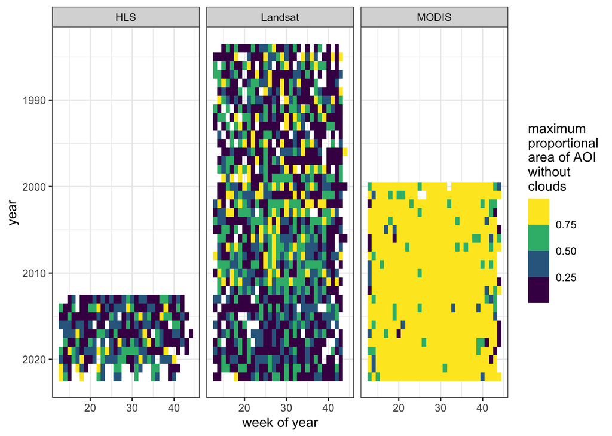

```r
sats %>%
  group_by(year, week, sat) %>%
  summarize(p_area = max(p_area)) %>%
  ggplot(.) +
  geom_tile(aes(x = week, y = year, fill = p_area)) +
  facet_grid(. ~ sat)+
  theme_bw() +
  scale_y_reverse() +
  scale_fill_viridis_b() +
  labs(x = 'week of year',
         fill = 'maximum\nproportional\narea of AOI\nwithout\nclouds')
```

Figure 5. Indication of maximum proportional area of AOI per week without clouds by satellite product.

And here, the number of images available per week that have at least 50% of our AOI available for Landsat and MODIS or 40% for our estimate for HLS for analysis. Because our estimate of HLS is calculated differently, we are allowing for a slightly more liberal aggregation to contribute to an output product.

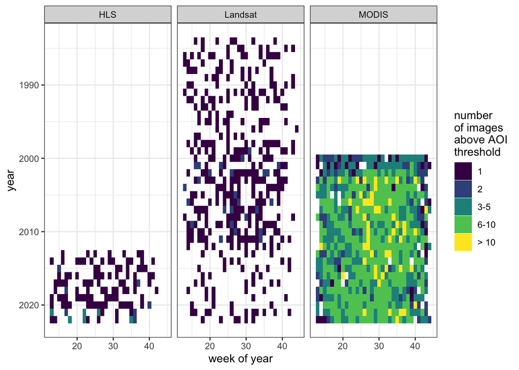

```r
sats %>%
  filter((sat == 'Landsat' & p_area >0.5) |
           (sat == 'MODIS' & p_area >0.5) |
           (sat == 'HLS' & p_area >0.4)) %>%
  group_by(year, week, sat) %>%
  summarize(img_count = n()) %>%
  mutate(img_bin = case_when(img_count == 1 ~ '1',
                             img_count == 2 ~ '2',
                             between(img_count, 3, 5) ~ '3-5',
                             between(img_count, 6, 10) ~ '6-10',
                             img_count > 10 ~ '> 10'),
         img_bin = factor(img_bin, levels = c('1', '2', '3-5', '6-10', '> 10')))%>%
  ggplot(.) +
  geom_tile(aes(x = week, y = year, fill = img_bin)) +
  facet_grid(. ~ sat)+
  theme_bw() +
  scale_y_reverse() +
  scale_fill_viridis_d() +
  labs(x = 'week of year',
         fill = 'number\nof images\nabove AOI\nthreshold')
```

Figure 6. Number of images above described threshold per week.

## Monthly Summaries

When the data are aggregated on a monthly basis, we can use other satellite constellations to produce a more consistent product. Note, the output raster is likely to be incomplete for HLS and Landsat products, as we can not guarantee that all pixels in our AOI are available for analysis given the limited number of images included in the output product.

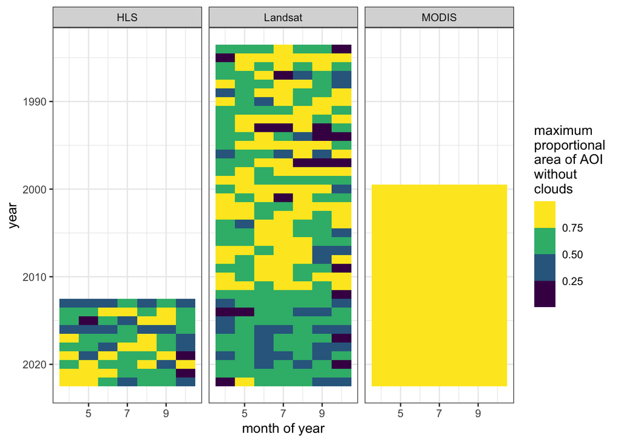

```r
sats %>%
  group_by(year, month, sat) %>%
  summarize(p_area = max(p_area))  %>%
  ggplot(.) +
  geom_tile(aes(x = month, y = year, fill = p_area)) +
  facet_grid(. ~ sat)+
  theme_bw() +
  scale_y_reverse() +
  scale_fill_viridis_b() +
  labs(x = 'month of year',
         fill = 'maximum\nproportional\narea of AOI\nwithout\nclouds')
```

Figure 7. Indication of maximum proportional area per month of AOI without clouds by satellite product.

Number of images that have at least 50% of AOI (Landsat/MODIS) or 40% of our AOI estimate (HLS) when aggregated to a monthly timestep:

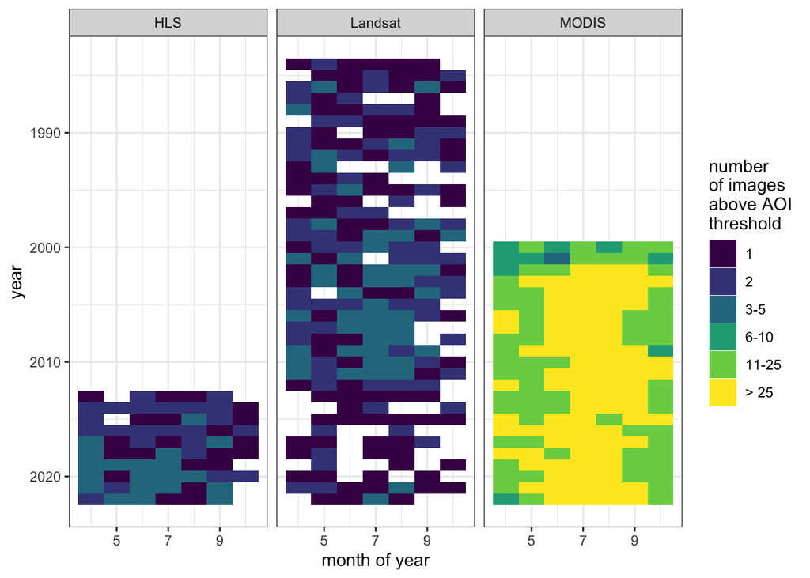

```r
sats %>%
  filter((sat == 'Landsat' & p_area >0.5) |
           (sat == 'MODIS' & p_area >0.5) |
           (sat == 'HLS' & p_area >0.4)) %>%
  group_by(year, month, sat) %>%
  summarize(img_count = n()) %>%
  mutate(img_bin = case_when(img_count == 1 ~ '1',
                             img_count == 2 ~ '2',
                             between(img_count, 3, 5) ~ '3-5',
                             between(img_count, 6, 10) ~ '6-10',
                             between(img_count, 11, 25) ~ '11-25',
                             img_count > 25 ~ '> 25'),
         img_bin = factor(img_bin, levels = c('1', '2', '3-5', '6-10', '11-25', '> 25'))) %>%
  ggplot(.) +
  geom_tile(aes(x = month, y = year, fill = img_bin)) +
  facet_grid(. ~ sat)+
  theme_bw() +
  scale_y_reverse() +
  scale_fill_viridis_d() +
  labs(x = 'month of year',
         fill = 'number\nof images\nabove AOI\nthreshold')
```

# Next Steps

Given the constraints, caveats, and trade-offs described and shown above, we now need direction on what the output should look like to help guide our pipeline. This includes the temporal timestep, the raster pixel size, and the initial satellite product to start with.

## MODIS:

## HLS:

A big part of ‘novelty’ of the HLS acquisition and analysis pipeline is using [STAC](https://lpdaac.usgs.gov/resources/e-learning/getting-started-cloud-native-hls-data-python/) (the Spatialtemporal Asset Catalog) to gather and process/request images and we have not yet built out this pipeline beyond taking inventory of the available data. HLS data pipeline will require local storage and compute of the STAC-acquired image collections in order to process with clustering techniques and image segmentation.